# Forecasting U.S. Natural Gas Prices with Time Series Decomposition

Week #12 Assignment: Choosing the Best Training Size

Hayden Patterson

West Chester University

# 1 Data Description

## 1.1 Source and Sample

The time series is the monthly Henry Hub spot price of natural gas, in nominal US dollars per million BTU. The data come from the U.S. Energy Information Administration (EIA), obtained through DataHub: https://datahub.io/core/natural-gas. The full series runs from January 1997 to October 2026 (358 months).

Following the course guideline of using 150-200 of the most recent observations, this analysis uses the **latest 168 months (14 full years), from November 2012 to October 2026**. This window is long enough to estimate seasonality over many annual cycles, and it excludes older price regimes that may have little predictive value for current prices.

Natural gas prices are shaped by both seasonal demand (winter heating) and supply and market shocks. Several episodes in this window are visible in the series plot:

- **2012-2020:** prices are mostly low and stable, a period associated with the U.S. shale production boom, with short winter spikes (for example, early 2014).
- **2021-2022:** prices climb to the highest levels in the sample, with the 2022 peak coinciding with the global energy crisis following Russia’s invasion of Ukraine.
- **2023-2026:** prices fall back toward earlier levels, with another sharp winter spike at the start of 2026.

These large, irregular movements make the series a good test of whether decomposition can separate a regular seasonal pattern from the trend and random shocks.

```r
gas <- read.csv("https://raw.githubusercontent.com/88haypa-collab/STA321_f26/refs/heads/main/ForecastingwithDecomposition/monthly.csv")
sum(is.na(gas$Price))                       # check for missing values
```

```
## [1] 0
```

```r
n.row <- nrow(gas)
gas.recent <- tail(gas, 168)                # most recent 168 months
head(gas.recent, 1); tail(gas.recent, 1)    # should be 2012-11 and 2026-10
```

|  | Month | Price |
| --- | --- | --- |
| 191 | 2012-11 | 3.54 |

|  | Month | Price |
| --- | --- | --- |
| 358 | 2026-10 | 2.99 |

```r
write.csv(gas.recent, "gas_recent.csv", row.names = FALSE)   # submitted data file
```

## 1.2 Define Time Series Object

Since this is monthly data with an annual cycle, `frequency = 12` is used, and the series starts in November 2012. The plot below shows no steady upward or downward trend. Instead, the level shifts over time, with a large hump around 2022 and occasional sharp spikes.

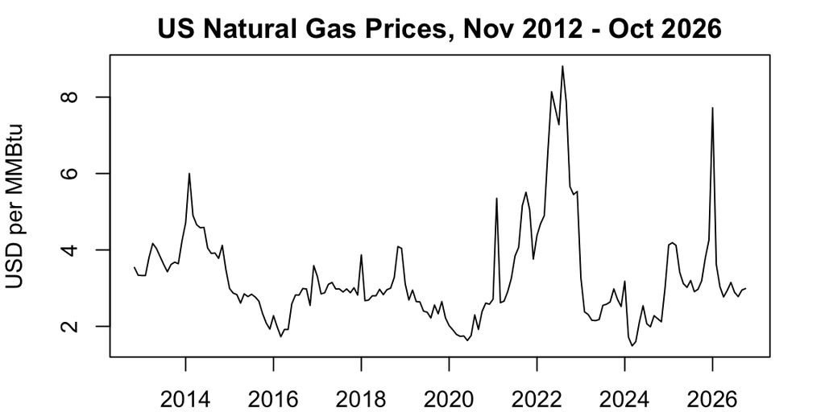

Monthly Henry Hub natural gas price, Nov 2012 - Oct 2026 (168 months).

```r
gas.ts <- ts(gas.recent$Price, frequency = 12, start = c(2012, 11))
par(mar = c(2, 4, 2, 2))
plot(gas.ts, main = "US Natural Gas Prices, Nov 2012 - Oct 2026",
     xlab = "", ylab = "USD per MMBtu")
```

# 2 Exploratory Analysis

## 2.1 Additive or Multiplicative? Raw vs. Log Scale

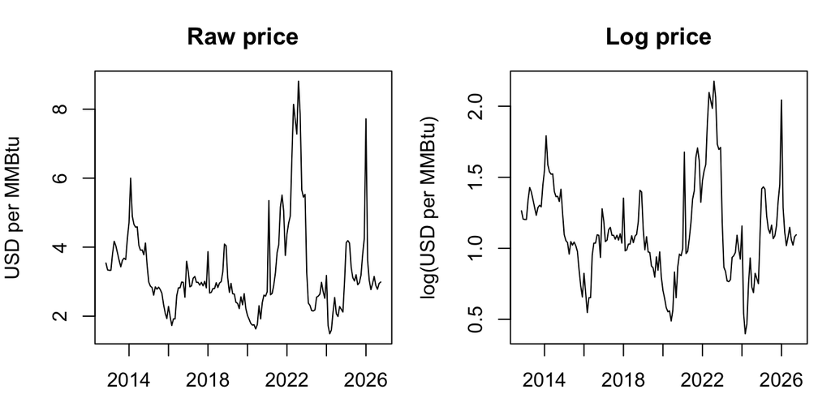

Raw (left) and log-transformed (right) monthly natural gas price. The log scale makes the size of the swings more even across the sample.

```r
par(mfrow = c(1, 2), mar = c(3, 4, 3, 1))
plot(gas.ts, main = "Raw price", xlab = "", ylab = "USD per MMBtu")
plot(log(gas.ts), main = "Log price", xlab = "", ylab = "log(USD per MMBtu)")
```

```r
par(mfrow = c(1, 1))
```

In the raw series, the swings are small when prices are low (2016-2019) and very large when prices are high (2022), which suggests the variability grows with the level, as in a multiplicative model. After the log transformation, the swings look more even across the whole sample. We therefore model the series on the log scale, where the multiplicative structure $y_t = T_t \times S_t \times E_t$ becomes additive: $\log(y_t) = \log(T_t) + \log(S_t) + \log(E_t)$.

## 2.2 Is There Seasonality?

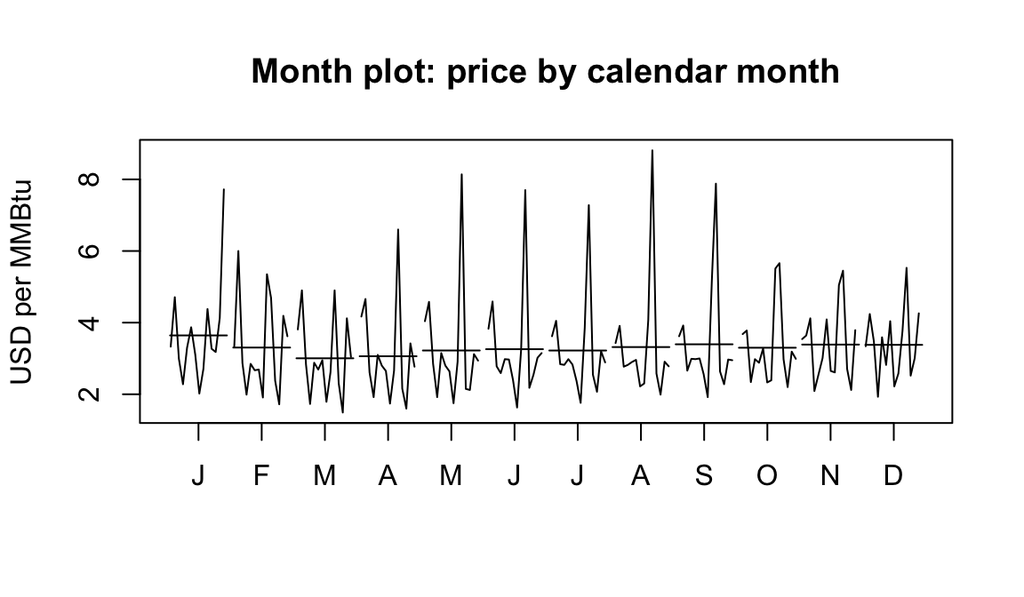

Month plot: price by calendar month. Horizontal lines are each month’s average across 2012-2026.

```r
monthplot(gas.ts, main = "Month plot: price by calendar month", ylab = "USD per MMBtu")
```

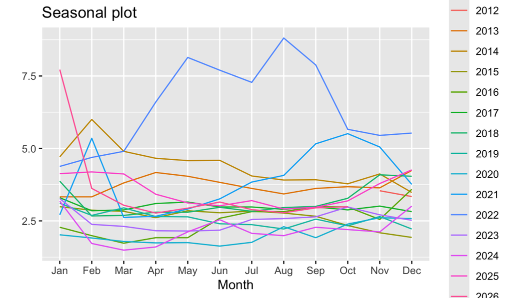

Seasonal plot: one line per year. The lines show no consistent shape, which indicates weak seasonality.

```r
ggseasonplot(gas.ts, year.labels = FALSE, main = "Seasonal plot")
```

The month plot shows each calendar month’s average price (the horizontal lines). The averages are fairly close to each other, from about 3.0 to 3.7 USD, with January highest and March lowest. These differences are small compared with the spread of prices within each month. The seasonal plot tells the same story: the yearly lines cross each other with no common shape, and the largest features are level shifts (2022) and one-off spikes (early 2014 and early 2026). So the seasonality in this series is present but weak, and trend and shocks dominate.

# 3 Decomposition

```r
log.gas.ts <- log(gas.ts)
```

## 3.1 Classical Decomposition

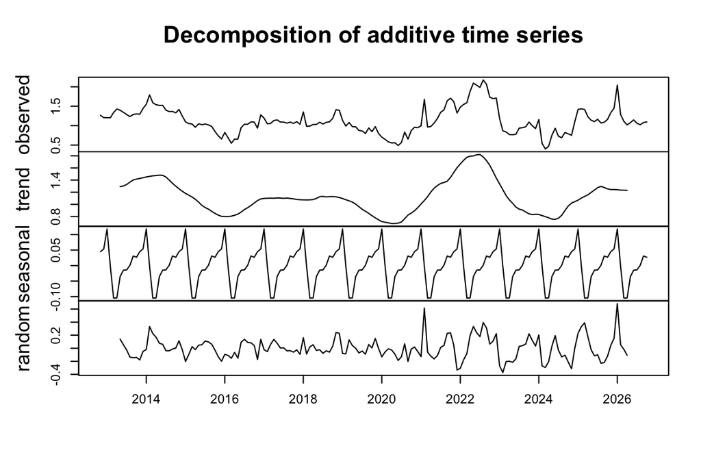

Classical additive decomposition of the log monthly natural gas price (Nov 2012 - Oct 2026): observed series, trend (centered 12-month moving average), fixed seasonal component, and random remainder.

```r
cls.decomp <- decompose(log.gas.ts, "additive")
par(mar = c(2, 2, 2, 2))
plot(cls.decomp, xlab = "")
```

## 3.2 STL Decomposition

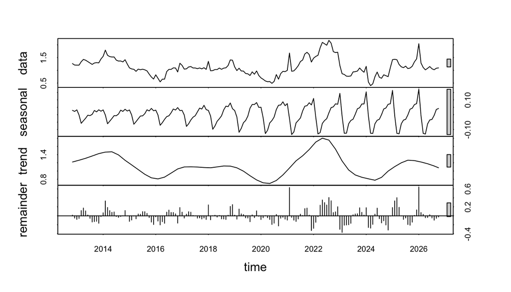

STL decomposition of the log monthly natural gas price (s.window = 12): observed data, seasonal, LOESS trend, and remainder. The gray bars at the right show the relative scale of each panel.

```r
stl.decomp <- stl(log.gas.ts, s.window = 12)
plot(stl.decomp)
```

Both methods give a similar picture. The trend is smooth and shows no steady direction: it falls through 2016, stays flat until 2019, dips in 2020, rises to a large peak in 2022, then falls back and recovers somewhat. The seasonal component is small, between roughly -0.10 and +0.07 on the log scale, much smaller than the movement in the trend, which confirms that seasonality is weak in this series.

The two methods differ in three ways. First, the classical trend is missing about six months at each end because of the centered moving average, while the STL trend covers the full sample. Second, the classical seasonal pattern repeats identically every year, whereas STL lets the seasonal shape change over time, and its amplitude grows noticeably in the later years. Third, the remainder in both methods still contains the large spikes in early 2021 and early 2026, and it is not random noise: it has long runs above and below zero, especially around 2022-2025, which means some structure is left in the remainder that decomposition did not capture. Because STL handles the ends of the series and allows a changing seasonal pattern, we use it for forecasting.

# 4 Forecasting with Decomposing

## 4.1 Training and Testing Data

The last 12 months (Nov 2025 - Oct 2026), one full seasonal cycle, are held out as the test set. The rest of the history is used for training. To study how the amount of training data affects forecast accuracy, four training sets with different sizes are used: 156, 120, 84, and 48 months. All four end in October 2025, so the same test set is used for every comparison, and only the starting point changes. Training size is treated as a tuning parameter.

```r
ini.data <- log(gas.recent$Price)      # modeling on the log scale
n0 <- length(ini.data)                 # 168

## training sets (all end at observation n0 - 12)
train.data01 <- ini.data[1:(n0-12)]
train.data02 <- ini.data[37:(n0-12)]
train.data03 <- ini.data[73:(n0-12)]
train.data04 <- ini.data[109:(n0-12)]

## test set: the last 12 observations, kept on the raw price scale for error calculation
test.data <- gas.recent$Price[(n0-11):n0]

## time series objects (start dates move forward 36 months each time)
train01.ts <- ts(train.data01, frequency = 12, start = c(2012, 11))
train02.ts <- ts(train.data02, frequency = 12, start = c(2015, 11))
train03.ts <- ts(train.data03, frequency = 12, start = c(2018, 11))
train04.ts <- ts(train.data04, frequency = 12, start = c(2021, 11))

## check sizes and end dates before going further
c(length(train01.ts), length(train02.ts), length(train03.ts), length(train04.ts), length(test.data))
```

```
## [1] 156 120  84  48  12
```

```r
c(end(train01.ts), end(train04.ts))    # both should end in 2025, month 10
```

```
## [1] 2025   10 2025   10
```

## 4.2 Forecasts

```r
## STL decomposition on each training set (log scale)
stl01 <- stl(train01.ts, s.window = 12)
stl02 <- stl(train02.ts, s.window = 12)
stl03 <- stl(train03.ts, s.window = 12)
stl04 <- stl(train04.ts, s.window = 12)

## Forecast the next 12 months with the naive method on the seasonally adjusted series
fcst01 <- forecast(stl01, h = 12, method = "naive")
fcst02 <- forecast(stl02, h = 12, method = "naive")
fcst03 <- forecast(stl03, h = 12, method = "naive")
fcst04 <- forecast(stl04, h = 12, method = "naive")

## Back-transform the point forecasts from logs to dollars
f01 <- exp(fcst01$mean)
f02 <- exp(fcst02$mean)
f03 <- exp(fcst03$mean)
f04 <- exp(fcst04$mean)

## Forecasts next to the actual test values
kable(round(cbind(Actual = test.data, n.156 = f01, n.120 = f02,
                  n.84 = f03, n.48 = f04), 2),
      caption = "Test-set actual prices (Nov 2025 - Oct 2026) and 12-month STL forecasts from four training sizes (USD per MMBtu).")
```

Test-set actual prices (Nov 2025 - Oct 2026) and 12-month STL forecasts from four training sizes (USD per MMBtu).

| Actual | n.156 | n.120 | n.84 | n.48 |
| --- | --- | --- | --- | --- |
| 3.79 | 3.24 | 3.25 | 3.22 | 3.14 |
| 4.26 | 3.20 | 3.20 | 3.17 | 3.24 |
| 7.72 | 3.26 | 3.25 | 3.22 | 3.45 |
| 3.62 | 2.98 | 2.99 | 2.99 | 2.80 |
| 3.04 | 2.68 | 2.66 | 2.64 | 2.73 |
| 2.77 | 2.71 | 2.69 | 2.67 | 2.81 |
| 2.94 | 2.89 | 2.89 | 2.89 | 3.13 |
| 3.15 | 2.94 | 2.94 | 2.94 | 3.23 |
| 2.89 | 2.99 | 2.98 | 3.00 | 3.19 |
| 2.78 | 3.10 | 3.10 | 3.11 | 3.21 |
| 2.95 | 3.19 | 3.19 | 3.21 | 3.29 |
| 2.99 | 3.19 | 3.19 | 3.19 | 3.19 |

All four training sizes give similar forecasts, centered around 2.6-3.5 USD. None of them anticipates the sharp spike in January 2026 (actual price 7.72 USD), which is the largest single forecast error.

## 4.3 Error Analysis

```r
## Forecast errors (actual - forecast), on the dollar scale
fc <- list(f01, f02, f03, f04)

MSE  <- sapply(fc, function(f) mean((test.data - f)^2))
MAPE <- sapply(fc, function(f) mean(abs((test.data - f) / test.data)))   # fraction, not percent

accuracy <- cbind(MSE = MSE, MAPE = MAPE)
row.names(accuracy) <- c("n.156", "n.120", "n. 84", "n. 48")
kable(accuracy, digits = 4,
      caption = "Forecast error on the 12-month test set by training size (MSE in squared USD; MAPE as a proportion).")
```

Forecast error on the 12-month test set by training size (MSE in squared USD; MAPE as a proportion).

|  | MSE | MAPE |
| --- | --- | --- |
| n.156 | 1.8462 | 0.1391 |
| n.120 | 1.8481 | 0.1400 |
| n. 84 | 1.8863 | 0.1438 |
| n. 48 | 1.7424 | 0.1529 |

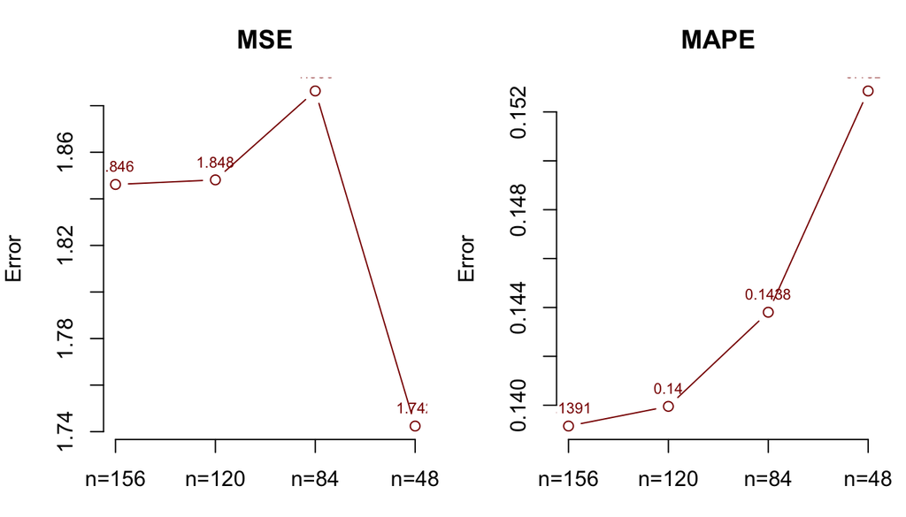

MSE (left) and MAPE (right) of the 12-month forecasts by training size.

```r
par(mfrow = c(1, 2), mar = c(3, 4, 3, 1))
labs <- c("n=156", "n=120", "n=84", "n=48")

plot(1:4, MSE, type = "b", col = "darkred", ylab = "Error", xlab = "",
     main = "MSE", axes = FALSE)
axis(1, at = 1:4, labels = labs); axis(2)
text(1:4, MSE, round(MSE, 3), pos = 3, cex = 0.7, col = "darkred")

plot(1:4, MAPE, type = "b", col = "darkred", ylab = "Error", xlab = "",
     main = "MAPE", axes = FALSE)
axis(1, at = 1:4, labels = labs); axis(2)
text(1:4, MAPE, round(MAPE, 4), pos = 3, cex = 0.7, col = "darkred")
```

```r
par(mfrow = c(1, 1))
```

# 5 Conclusion

This analysis decomposed the monthly Henry Hub natural gas price (Nov 2012 - Oct 2026) after a log transformation and used STL decomposition with a naive forecast of the seasonally adjusted series to forecast the last 12 months. Training size was treated as a tuning parameter, and four sizes (156, 120, 84, and 48 months) were compared on the same test set.

**Findings from the decomposition.** The series is dominated by its trend, which shifts without a steady direction (a large peak around 2022), and by sharp one-off spikes. The seasonal component is real but weak (roughly -0.10 to +0.07 on the log scale), with January slightly above the other months and March the lowest. STL was preferred over classical decomposition because it covers the whole sample and allows the seasonal pattern to change over time.

**Findings on training size.** The longer training sets (156, 120, and 84 months) performed almost identically, with MAPE of about 0.139, 0.140, and 0.144. The shortest set (48 months) had the worst MAPE, about 0.153. MSE gave a different ranking: the 48-month set had the lowest MSE (about 1.74, compared with about 1.85-1.89 for the others). This disagreement comes from one observation. In January 2026 the price jumped to 7.72 USD, and no model predicted it, so that single month dominates the MSE. When that month is excluded, the longer training sets have clearly smaller errors than the 48-month set (MSE of about 0.20 versus 0.25). Based on MAPE, and on typical months without the spike, a training size of **156 months** is best, although the gap between 156 and 120 months is too small to call a real difference. Very short training windows do worse because the seasonal pattern and trend are estimated from only four years of data.

**Limitations.** Forecast accuracy is modest for all sizes. The naive method carries the last seasonally adjusted value forward, so the forecasts are essentially flat plus a small seasonal pattern and cannot anticipate spikes or turning points. The test set has only 12 points, one of which is an extreme outlier, and results come from a single train-test split, so the ranking of training sizes may not hold for a different forecast window. Because seasonality is weak, decomposition-based forecasting adds little here beyond a naive forecast; models that can capture changing levels and volatility, such as the exponential smoothing models in the next module, are a natural next step.